# PM 566 Midterm Project

Author

Ziquan ‘Harrison’ Liu

# Requried packages

```r
library(tidyverse)  # dplyr, ggplot2, readr, string tools, plotting
library(dplyr)      # explicit for pipes and data wrangling
library(ggplot2)    # ggplot plotting
library(readr)      # fast/read_csv
library(stringr)    # string cleanup / regex
library(lubridate)  # work with dates (for stock update timestamps)
library(knitr)      # nice summary tables via kable()
library(kableExtra) # styling kable() for report-quality tables
library(maps)       # state map polygons for U.S. choropleth
library(countrycode) # optional helper if we ever need state mapping
library(forcats)    # reorder factors for nicer plots (top providers)
library(patchwork)    # to combine multiple ggplots into one figure grid
library(ggcorrplot)   # nice correlation heatmaps; install.packages("ggcorrplot") if missing
```

# 1. Introduction

## Description of Dataset: The dataset I utilzied was a national registry of influenza (flu) vaccination provider locations published by the U.S. Centers for Disease Control and Prevention (CDC) through the Vaccines.gov platform. The dataset contained point-level information on health care sites (e.g., pharmacies, clinics, health departments) that report offering influenza vaccination to the public. The dataset was designed to support public-facing vaccine finder tools and programmatic monitoring of geographic access to flu vaccination. There are 28 colomns and 202652 observations included in this dataset. In other words, 202,652 locations across 53 state or territorial codes. Temporal stamps reflect inventory/operational updates from 2023-08-17 through 2024-08-01.

## Primary Question: How are flu vaccination provider locations distributed across the United States, and what patterns emerge when examining provider characteristics such as minimum eligible age?

# 2. Data preparing

```r
# 2.1Read the dataset
fluvacall = read.csv("/Users/ldh/Library/Mobile Documents/com~apple~CloudDocs/USC PhD/STUDY DOCUMENTS/Fall 2025/PM 566/Midterm/Potential Dataset/Vaccines.gov__Flu_vaccinating_provider_locations_20251026.csv")
```

```r
# 2.2 Wrangle & standardize variables being analyzed
## provider_chain: a simplified provider “brand” from loc_name
## vaccine_type: the general product category (“Flu Shot”, “Flu Shot (65+)”, etc.) from searchable_name
## age_group: extract age eligibility like “65+”
## last_update_date: parsed quantity_last_updated
## days_since_update: how stale the stock info is (use Sys.Date() for “today”)
## state / lat / lon kept for mapping
## in_stock_flag and supply_level for availability
# --- Data Prep: create cleaned analytic dataset
# --- Data Prep: create cleaned analytic dataset
fluvac <- fluvacall %>%                                                   # start with raw data
  mutate(
    provider_chain = str_squish(loc_name),                                  # collapse extra spaces in provider name
    vaccine_type   = str_squish(searchable_name),                            # human-readable vaccine label such as "Flu Shot", "Flu Shot"
    age_group      = if_else(str_detect(searchable_name, "65\\+"),
                              "65_plus",           # pull explicit age info if mentioned (e.g. "65+")
                       if_else(str_detect(searchable_name, "Nasal Spray"),  # nasal spray often used for younger, generally healthy non-pregnant <50
                              "younger_adult_child",
                              "all_ages_general")),                          # fallback if not specifically flagged
    last_update_date = suppressWarnings(lubridate::ymd(quantity_last_updated)),  # parse last stock update "YYYY-MM-DD" string into Date
    days_since_update = as.numeric(Sys.Date() - last_update_date),          # how many days since that location last reported stock, proxy for freshness
    state = loc_admin_state,                                                # 2-letter state / territory code (e.g. "CA", "MA","NC")
    lat = latitude,                                                         # latitude coordinate for mapping
    lon = longitude,                                                        # longitude coordinate for mapping
    in_stock_flag = in_stock,                                               # TRUE/FALSE if the location reports flu vaccine in stock
    supply_level_clean = supply_level                                      # numeric / ordinal indicator of how much supply reported
  ) %>%
  filter(!is.na(lat), !is.na(lon), !is.na(state))                            # drop rows with missing geolocation / state so maps don't break
## Reasons to conduct above:
### selecting the variables that most relavant to the primary question before doing analysis
### extracting “age eligibility” signals directly from searchable_name because my research question explicitly expected to consider “minimum eligible age.
### by creating days_since_update leting us discuss supply recency at each site, tying directly to “vaccine supply updates” in the research question.
### keeping lat, lon, and state, which will be used to check geographic distribution like  mapped site locations by coordinates in previous labs using leaflet/ggplot.
```

# 3. Exploratory Analysis

```r
# 3.1 Dataset size and basic structure (Objective: How big is fluvac and what variables do we have)
## basic structure, size, and variable types
fluvac_overview <- tibble(                                                   # create a tibble summarizing structure w/o printing raw head()
  n_rows         = nrow(fluvac),                                          # total number of provider-location rows
  n_cols         = ncol(fluvac),                                          # total number of variables/columns
  last_update_min = min(fluvac$last_update_date, na.rm = TRUE),           # earliest stock timestamp recorded
  last_update_max = max(fluvac$last_update_date, na.rm = TRUE)            # most recent stock timestamp recorded
)
fluvac_overview
```

```
# A tibble: 1 × 4
  n_rows n_cols last_update_min last_update_max
   <int>  <int> <date>          <date>
1 202640     38 2023-08-17      2024-08-01
```

```r
#
var_names   <- names(fluvac)    # list of variable names
var_names
```

```
 [1] "provider_location_guid" "loc_store_no"           "loc_phone"
 [4] "loc_name"               "loc_admin_street1"      "loc_admin_street2"
 [7] "loc_admin_city"         "loc_admin_state"        "loc_admin_zip"
[10] "sunday_hours"           "monday_hours"           "tuesday_hours"
[13] "wednesday_hours"        "thursday_hours"         "friday_hours"
[16] "saturday_hours"         "web_address"            "pre_screen"
[19] "insurance_accepted"     "walkins_accepted"       "provider_notes"
[22] "searchable_name"        "in_stock"               "supply_level"
[25] "quantity_last_updated"  "latitude"               "longitude"
[28] "category"               "provider_chain"         "vaccine_type"
[31] "age_group"              "last_update_date"       "days_since_update"
[34] "state"                  "lat"                    "lon"
[37] "in_stock_flag"          "supply_level_clean"
```

```r
# 3.2 Checking categories that being analyzed later
# EDA: key categorical summaries (provider brand, product type, age group)
provider_counts <- fluvac %>%
  count(provider_chain, sort = TRUE) %>%           # how many rows per provider brand/chain
  mutate(pct = 100 * n / sum(n))                   # share of total locations
#
vaccine_type_counts <- fluvac %>%
  count(vaccine_type, sort = TRUE) %>%             # how many rows per vaccine type label
  mutate(pct = 100 * n / sum(n))                   # share of total
#
age_group_counts <- fluvac %>%
  count(age_group, sort = TRUE) %>%                # how many rows per inferred eligibility group
  mutate(pct = 100 * n / sum(n))                   # % of all sites
vaccine_type_counts
```

```
                             vaccine_type     n      pct
1                                Flu Shot 75693 37.35343
2 Flu Shot (65+, high-dose or adjuvanted) 62786 30.98401
3                     Flu Shot (Egg free) 56017 27.64360
4                         Flu Nasal Spray  8144  4.01895
```

```r
age_group_counts
```

```
            age_group      n      pct
1    all_ages_general 131710 64.99704
2             65_plus  62786 30.98401
3 younger_adult_child   8144  4.01895
```

```r
### the output below was used for providing characteristics such as type [≈provider_chain], minimum eligible age [≈age_group], and vaccine supply updates, so need to know if  have enough variation in those variables to analyze.
```

```r
# 3.3 numrix summaries with sapply() style (distribution sanity check)
numeric_vars <- fluvac %>%                                                               # select numeric-ish variables
  select(days_since_update, supply_level_clean, lat, lon)                                # timing of updates, supply, and coordinates for mapping
num_summary <- sapply(numeric_vars, summary)                                             # summary() for each numeric variable (Min/1Q/Median/Mean/3Q/Max)
num_missing <- sapply(numeric_vars, function(x) sum(is.na(x)))                           # number of NAs by numeric variable
## wrap numeric summary into a nicer long-format table for kable (so no raw console dump):
num_summary_tbl <- as.data.frame(t(num_summary)) %>%                                     # transpose so each row = variable
  mutate(var = rownames(.),
         n_missing = num_missing[ var ]) %>%                                             # attach missing counts per variable
  relocate(var)
#
kable(num_summary_tbl,
      caption = "Distribution summaries for numeric variables in `fluvac` (with missing counts)") %>%  # publishable numeric summary  #
  kable_styling(full_width = FALSE, position = "center",
                bootstrap_options = c("striped","hover","condensed","responsive")) %>%
  row_spec(0, bold = TRUE, background = "#756bb1", color = "white") %>%
  row_spec(1:nrow(num_summary_tbl), background = c("#efedf5","white"))                                  #
```

Distribution summaries for numeric variables in `fluvac` (with missing counts)

|  | var | Min. | 1st Qu. | Median | Mean | 3rd Qu. | Max. | n_missing |
| --- | --- | --- | --- | --- | --- | --- | --- | --- |
| days_since_update | days_since_update | 451.00000 | 451.00000 | 454.00000 | 498.636701 | 571.00000 | 801.00000 | 0 |
| supply_level_clean | supply_level_clean | -1.00000 | 0.00000 | 0.00000 | 0.024393 | 0.00000 | 4.00000 | 0 |
| lat | lat | 17.96489 | 33.69613 | 38.60332 | 37.397446 | 41.31921 | 71.29726 | 0 |
| lon | lon | -176.65900 | -97.56295 | -85.65537 | -90.829963 | -78.69288 | -64.88893 | 0 |

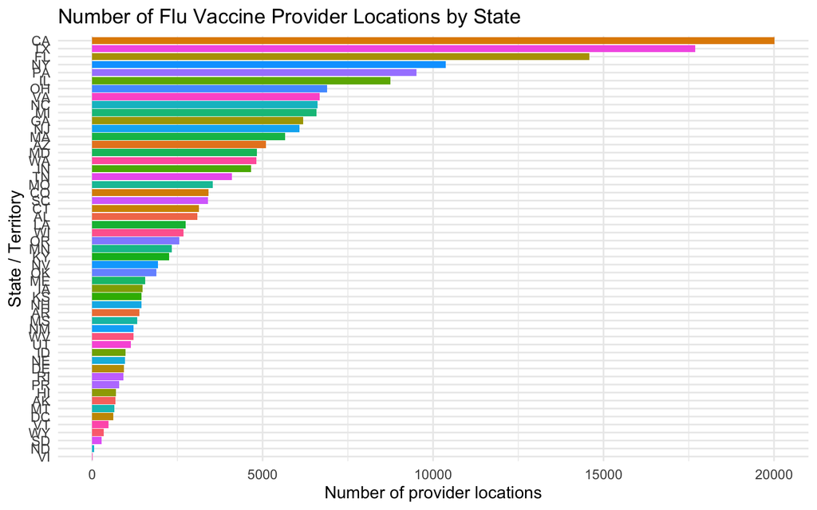

```r
# 3.4 Visualize basic distributions:
## distribution of sites per state (bar plot)
state_counts <- fluvac %>%
  count(state, name = "num_sites") %>%                           # count locations by 2-letter state
  arrange(desc(num_sites))                                       # rank states by number of sites
#
ggplot(state_counts, aes(x = reorder(state, num_sites), y = num_sites, fill = state)) +
  geom_col(show.legend = FALSE) +                                # bar height = number of sites
  coord_flip() +                                                 # flip for readability
  labs(
    title = "Number of Flu Vaccine Provider Locations by State", # figure title
    x = "State / Territory",                                     # x-axis label
    y = "Number of provider locations"                           # y-axis label
  ) +
  theme_minimal(base_size = 12)                                  # clean theme
```

```r
### The output below showed states with the highest counts of listed flu vaccine providers include [Top 10: CA, TX, FL, NY, PA,IL,OH,VA,NC,MI], reflecting high retail pharmacy density and population size. States/territories with the fewest listed providers tend to be smaller-population jurisdictions or territories.
```

```r
## checking in-stock status and stock recency
stock_summary <- fluvac %>%
  mutate(
    stock_status = if_else(isTRUE(in_stock_flag), "In stock", "Not in stock / Unknown")  # readable flag
  ) %>%
  group_by(stock_status) %>%
  summarise(
    n_sites = n(),                                                  # number of sites in each status
    median_days_since_update = median(days_since_update, na.rm=TRUE),  # recency of last reported stock info
    .groups = "drop"
  )
#
kable(stock_summary,
      caption = "Stock status & reporting recency across flu vaccine provider locations") %>%
  kable_styling(full_width = FALSE, position = "center",
                bootstrap_options = c("striped","hover","condensed","responsive")) %>%
  row_spec(0, bold = TRUE, background = "#756bb1", color = "white") %>%        # styled header like earlier tables
  row_spec(1:nrow(stock_summary), background = c("#efedf5","white"))           # alternating row colors
```

Stock status & reporting recency across flu vaccine provider locations

| stock_status | n_sites | median_days_since_update |
| --- | --- | --- |
| Not in stock / Unknown | 202640 | 454 |

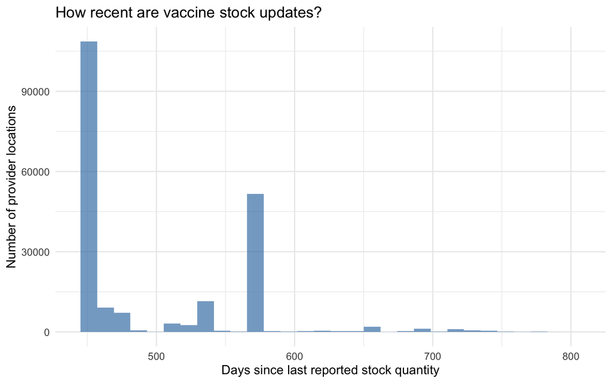

```r
# distribution of days since last stock update
ggplot(fluvac, aes(x = days_since_update)) +
  geom_histogram(bins = 30, fill = "steelblue", alpha = 0.7) +   # histogram of reporting freshness   #
  labs(
    title = "How recent are vaccine stock updates?",
    x = "Days since last reported stock quantity",
    y = "Number of provider locations"
  ) +
  theme_minimal(base_size = 12)
```

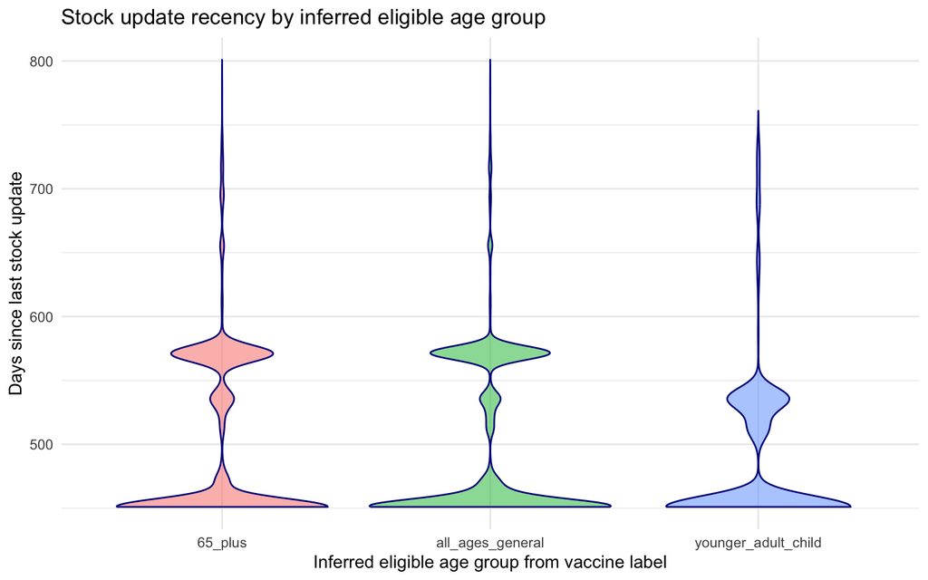

```r
## Violin plot of days_since_update by age_group
p_violin_age <- ggplot(
  fluvac,
  aes(x = age_group, y = days_since_update, fill = age_group)
) +
  geom_violin(alpha = 0.5, color = "darkblue") +                                                  # violin shows full distribution shape
  scale_y_continuous(name = "Days since last stock update") +                             # y-axis label
  labs(
    title = "Stock update recency by inferred eligible age group",
    x = "Inferred eligible age group from vaccine label"
  ) +
  theme_minimal(base_size = 11) +
  theme(legend.position = "none")
p_violin_age
```

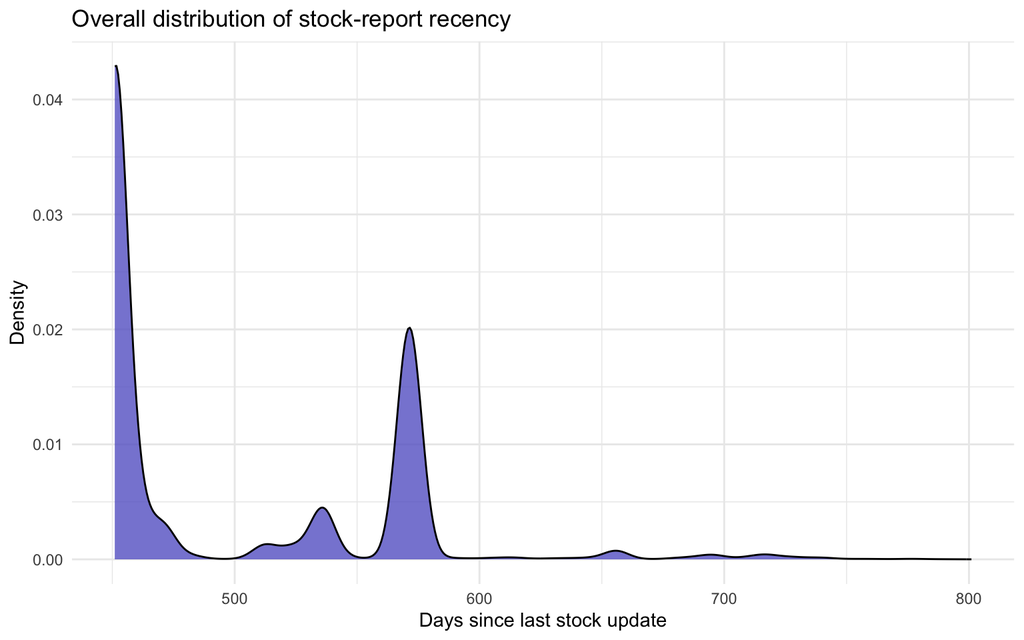

```r
## Density of days_since_update (freshness overall)
p_density_fresh <- ggplot(
  fluvac,
  aes(x = days_since_update)
) +
  geom_density(fill = "#66c", alpha = 0.8) +                                           # smoothed density curve (like your cancer incidence density plot)
  labs(
    title = "Overall distribution of stock-report recency",
    x = "Days since last stock update",
    y = "Density"
  ) +
  theme_minimal(base_size = 11)
p_density_fresh
```

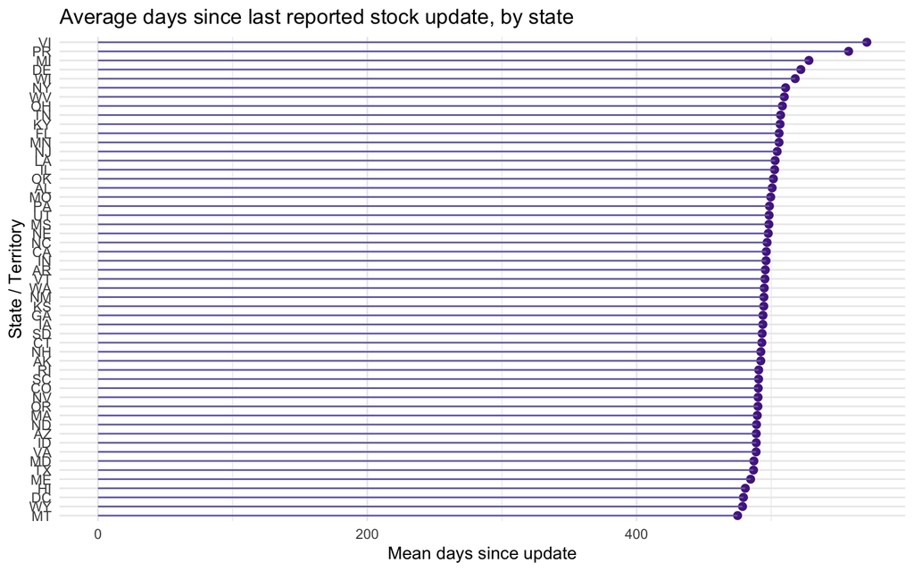

```r
## Average days_since_update by state (line or lollipop-style)
state_fresh <- fluvac %>%
  group_by(state) %>%
  summarise(mean_days = mean(days_since_update, na.rm = TRUE)) %>%
  arrange(desc(mean_days))
#
p_state_line <- ggplot(
  state_fresh,
  aes(x = reorder(state, mean_days), y = mean_days)
) +
  geom_point(color = "#54278f", size = 2) +                                               # dot plot showing average recency per state
  geom_segment(aes(xend = reorder(state, mean_days),
                   y = 0,
                   yend = mean_days),
               color = "#756bb1") +                                                       # lollipop style from 0 up to the point
  coord_flip() +
  labs(
    title = "Average days since last reported stock update, by state",
    x = "State / Territory",
    y = "Mean days since update"
  ) +
  theme_minimal(base_size = 11)
p_state_line
```

# 4. Preliminary Results

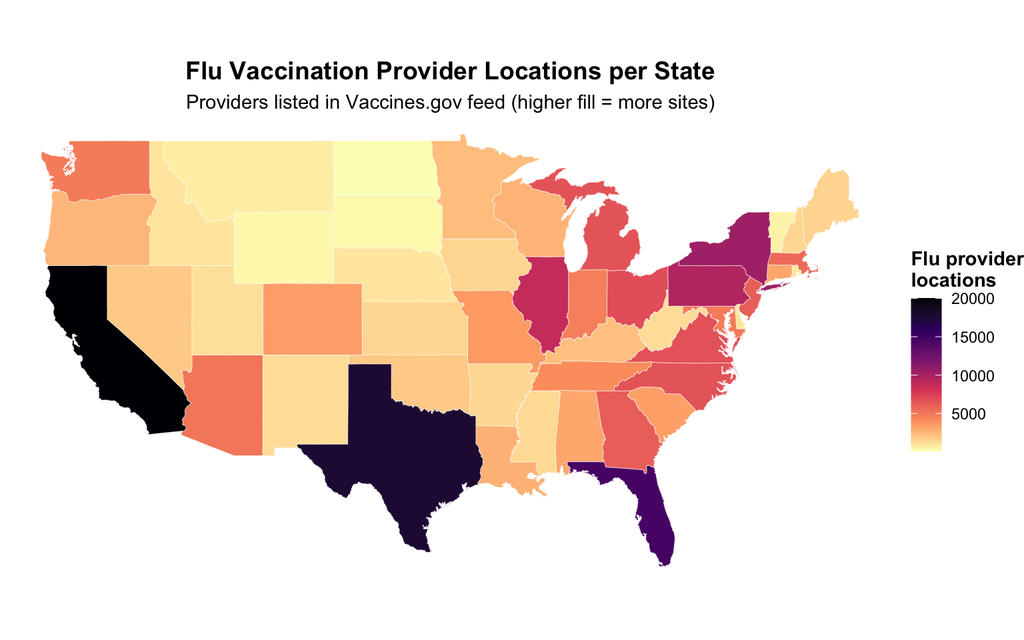

```r
# 4.1 Results: provider locations per state mapped
state_counts_map <- fluvac %>%
  mutate(state_full = tolower(state.name[match(state, state.abb)])) %>%   # convert "CA" -> "california" etc.
  count(state_full, name = "num_sites")                                   # how many provider locations per state_full
#
usa_map <- map_data("state")                                              # polygon coords for lower 48 + AK, HI
#
chorodata <- usa_map %>%
  left_join(state_counts_map, by = c("region" = "state_full"))            # attach counts to map polygons
#
ggplot(chorodata, aes(long, lat, group = group, fill = num_sites)) +
  geom_polygon(color = "white", size = 0.1) +                             # draw each state polygon
  scale_fill_viridis_c(option = "magma", direction = -1, na.value = "grey90",
                       name = "Flu provider\nlocations") +                # color scale similar to earlier global maps
  coord_quickmap() +                                                      # keeps aspect ratio sensible for maps
  labs(
    title = "Flu Vaccination Provider Locations per State",
    subtitle = "Providers listed in Vaccines.gov feed (higher fill = more sites)",
    x = NULL, y = NULL
  ) +
  theme_void() +                                                          # map-focused theme
  theme(
    plot.title = element_text(face = "bold", hjust = 0.5, size = 14),
    plot.subtitle = element_text(hjust = 0.5, size = 11),
    legend.title = element_text(face = "bold")
  )
```

## Brief Reports: Provider locations are dense in populous states (e.g., CA, TX, FL, and NY) and more sparse in smaller-population states and certain rural regions. This mirrors what we saw in environmental monitoring site maps, where spatial coverage clusters around populated corridors.The reason of such differences might be states with large urban populations show more listed vaccination sites.

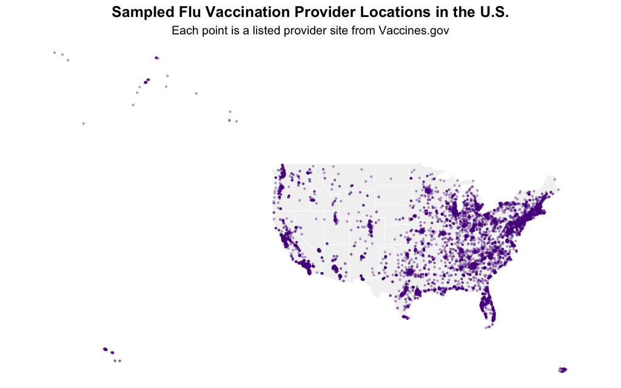

```r
# 4.2 Point map of all provider locations
## quick point map of provider locations (sampled)
set.seed(12)                                                               # reproducible sample for plotting
fluvac_sample <- fluvac %>% sample_n(min(10000, n()))                       # take up to 10k points for visualization

usa_states <- map_data("state")                                            # U.S. basemap polygons

ggplot() +
  geom_polygon(data = usa_states,
               aes(x = long, y = lat, group = group),
               fill = "grey95", color = "white", linewidth = 0.2) +        # light gray U.S. map background
  geom_point(data = fluvac_sample,
             aes(x = lon, y = lat),
             alpha = 0.3, size = 0.5, color = "purple4") +                 # purple-ish dots for provider sites
  coord_quickmap() +
  labs(
    title = "Sampled Flu Vaccination Provider Locations in the U.S.",
    subtitle = "Each point is a listed provider site from Vaccines.gov",
    x = NULL, y = NULL
  ) +
  theme_void() +
  theme(
    plot.title = element_text(face = "bold", size = 14, hjust = 0.5),
    plot.subtitle = element_text(size = 11, hjust = 0.5)
  )
```

## Brief Reports: The result above revealed the spatial distribution of influenza vaccine provider sites across the United States. A point map representation of sampling provider sites (up to 10,000 locations) illustrated that flu vaccine providers are extensively distributed throughout the country, with much larger densities in highly populated areas, especially along the East Coast, California, Texas, and some sections of the Midwest. In contrast, rural and less densely inhabited regions, such as the Mountain West and some sections of the Great Plains, had a relatively lower number of provider locations. This geographical distribution pattern corresponded with anticipated population and healthcare infrastructure density, indicating increased provider supply in metropolitan areas where demand is greatest. infrastructure patterns.

```r
# 4.3 Results: Minimum eligible age: looking at what fraction of locations explicitly advertise high-dose/adjuvanted doses for adults 65+ vs. general flu shots vs. nasal spray (often pediatrics/younger adults):
age_mix <- fluvac %>%
  group_by(age_group) %>%                                            # "65_plus", "younger_adult_child", "all_ages_general"
  summarise(
    n_sites = n(),                                                   # number of sites offering that product type
    pct_sites = 100 * n_sites / nrow(fluvac),                        # share of all sites
    .groups = "drop"
  )
#
kable(age_mix,
      caption = "Flu Vaccine Eligibility Focus (based on product labeling at site)") %>%
  kable_styling(full_width = FALSE, position = "center",
                bootstrap_options = c("striped","hover","condensed","responsive")) %>%
  row_spec(0, bold = TRUE, background = "#756bb1", color = "white") %>%
  row_spec(1:nrow(age_mix), background = c("#efedf5","white"))
```

Flu Vaccine Eligibility Focus (based on product labeling at site)

| age_group | n_sites | pct_sites |
| --- | --- | --- |
| 65_plus | 62786 | 30.98401 |
| all_ages_general | 131710 | 64.99704 |
| younger_adult_child | 8144 | 4.01895 |